# Reproducible Research Peer Assessment 1

#### **QUESTION 1: Loading and preprocessing the data**

1. Get the data from the file in the right format and convert the ‘date’ field to date type
2. Show the main facts about the raw data for exploration

```r
setwd("C:/Users/xgs/Desktop/Coursera_Data _Science/5-Reproducible Research/Week 2")
Activity <- read.csv(paste(getwd(),"/Assignment/activity.csv", sep=""), header = TRUE
                , sep = "," , colClasses = c("numeric","Date","numeric"))
names(Activity) <- c("Steps","Date","Interval")
```

#### **QUESTION 2: What is mean total number of steps taken per day?**

*Note: Because it seems that the few-steps values have frequencies much more higher than the rest, is difficult to see any interesting feature in this chart. To get more information let’s change the* **Y scale to an square root of counts.** *Doing so we can appreciate more detail*

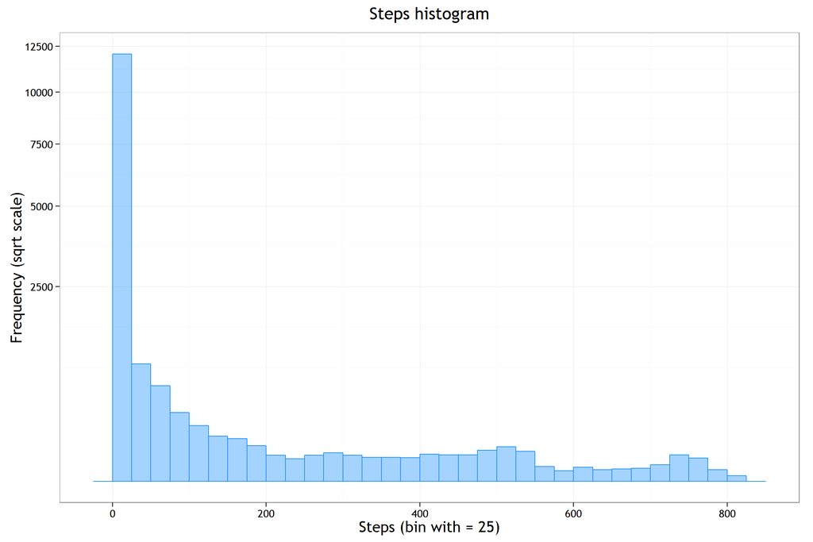

```r
##      Remove NA
ActivityClean <- Activity[complete.cases(Activity) == TRUE,]

##      Aggregate steps by Date and format of the new dataset
ActivityCleanByDay <- aggregate(Steps ~ Date, data = Activity, FUN = mean)
##      Evaluation of mean and median from the total steps by day
meanActivityCleanByDay <- mean(ActivityCleanByDay$Steps)
medianActivityCleanByDay <- median(ActivityCleanByDay$Steps)

##      Loads fonts and prepares aesthetics of the ggplot histogram
windowsFonts(A=windowsFont("Trebuchet MS"))
gObj <- ggplot(ActivityClean, aes(x = Steps))
gObj <- gObj + geom_histogram(colour = "dodgerblue", fill = "dodgerblue"
                , binwidth = 25, font_family = "A", alpha = 0.4)
gObj <- gObj + theme_bw(base_family = "A", base_size = 14)
gObj <- gObj + scale_y_sqrt()
gObj <- gObj + xlab("Steps (bin with = 25)")
gObj <- gObj + ylab("Frequency (sqrt scale)")
gObj <- gObj + ggtitle("Steps histogram")
gObj <- gObj + theme(axis.title = element_text(family = "A", size = 16)
                , title = element_text(family = "A", size = 15)
                , plot.title = element_text(vjust = 2))
print(gObj)
```

#### **QUESTION 3: What is the average daily activity pattern**

1. Make a time series plot of the 5-minute interval (x-axis) and the average number of steps taken, averaged across all days (y-axis)
2. Which 5-minute interval, on average across all the days in the dataset, contains the maximum number of steps?

*Procedure: aggregate Steps by Interval, determine the maximum value in the array and plot the data*

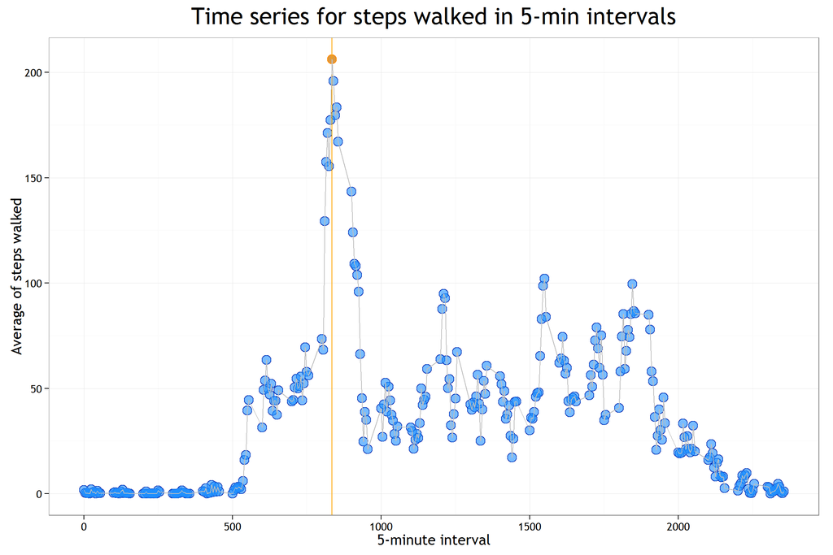

```r
##      Aggregate steps by Interval and format of the new dataset
ActivityCleanByStep <- aggregate(Steps ~ Interval, data = Activity, FUN = mean)

##      Determine which is the maximum value for steps in the dataset
indexMax <- as.numeric(which(ActivityCleanByStep$Steps == max(ActivityCleanByStep$Steps)))
valueMax <- ActivityCleanByStep[indexMax,]

##      Formats a plot that displays the steps taken for every interval and marks the maximum value
gObj <- ggplot(ActivityCleanByStep, aes(Interval,Steps, font_family = "A"))
gObj <- gObj + theme_bw(base_family = "A", base_size = 14)
gObj <- gObj + geom_point(color = "darkblue", size = 4.5, pch = 21)
gObj <- gObj + geom_point(color = "dodgerblue", size = 4.5, alpha = 0.6)
gObj <- gObj + geom_point(data = valueMax, color = "darkorange", pch = 21, size = 4.5)
gObj <- gObj + geom_point(data = valueMax, color = "darkorange", alpha = 0.75, size = 4.5)
gObj <- gObj + geom_vline(aes(xintercept = valueMax$Interval), colour="orange")
gObj <- gObj + geom_line(color = "gray")
gObj <- gObj + xlab("5-minute interval")
gObj <- gObj + ylab("Average of steps walked")
gObj <- gObj + ggtitle("Time series for steps walked in 5-min intervals")
gObj <- gObj + theme(axis.title = element_text(family = "A", size = 15)
                , title = element_text(family = "A", size = 20)
                , plot.title = element_text(vjust = 2))
print(gObj)
```

*Determination of the interval which contains the most steps in average along the date range*  
*The interval containing the most steps (orange point) is:*

- **Index in data array:** 104
- **Interval:** 835
- **Steps:** 206.17

#### **QUESTION 4: Imputing missing values**

1. Calculate and report the total number of missing values in the dataset.
2. Devise a strategy for filling in all of the missing values in the dataset.
3. Create a new dataset with the missing data filled in.
4. Make a histogram of the total number of steps taken each day, calculate the mean and median. Evaluate differences with the non-NA dataset and estimate the impact of imputation.

*Total missing values from the original dataset*

```r
##      Marks the NA by a factor variable
Activity$IsNa <- as.factor(!complete.cases(Activity))
##      Stores the summary for the factor variable
SummIsNA <- summary(Activity$IsNa)
SummIsNA
```

```
## FALSE  TRUE
## 15264  2304
```

*The amount of NA values in the original dataset is:*

- **Total NA:** 2304
- **NA as % of Total:** 13.11%

*Procedure: Im using the strategy of replacing NA by the mean value of steps for the corresponding 5 minutes interval. This seems to me a better approach than imputing the mean of steps by day, since there are some days on the recordset without a valid value.*

```r
##      Merge the Activity dataset with the dataframe of averages by day using the Interval field.
Activity <- merge(Activity[,1:3],ActivityCleanByStep,by.x = "Interval",by.y = "Interval")
names(Activity) <- c("Interval","Steps","Date","ImputedSteps")

##      A new field to store the results of the imputation. For NA it sets the ImputedSteps (coming from the averages), for non-NA, the original steps value is set
Activity$AllSteps <- as.numeric(0)
Activity[which(is.na(Activity$Steps)),]$AllSteps <- Activity[which(is.na(Activity$Steps)),]$ImputedSteps
Activity[which(!is.na(Activity$Steps)),]$AllSteps <- Activity[which(!is.na(Activity$Steps)),]$Steps
```

*The new Activity dataset contains the imputed values for steps, the histogram looks like this* *Note: As in the previous case, the Y scale matters to see details, so I’m using an* **squared Y scale**

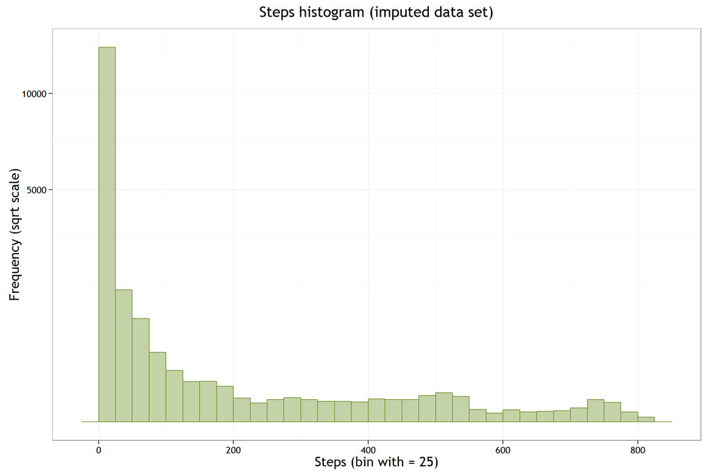

```r
##      Gets the mean and median for the total steps taken by day from the imputed values
ActivityByDay <- aggregate(AllSteps ~ Date, data = Activity, FUN = mean)
names(ActivityByDay) <- c("Date","Steps")

##      Evaluation of mean and median from the total steps by day
meanActivityByDay <- mean(ActivityByDay$Steps)
medianActivityByDay <- median(ActivityByDay$Steps)

##      Plotting the histogram for the imputated steps dataset
gObj <- ggplot(Activity, aes(x = AllSteps))
gObj <- gObj + geom_histogram(colour = "olivedrab", fill = "olivedrab"
                , binwidth = 25, font_family = "A", alpha = 0.4)
gObj <- gObj + theme_bw(base_family = "A", base_size = 14)
gObj <- gObj + scale_y_sqrt()
gObj <- gObj + xlab("Steps (bin with = 25)")
gObj <- gObj + ylab("Frequency (sqrt scale)")
gObj <- gObj + ggtitle("Steps histogram (imputed data set)")
gObj <- gObj + theme(axis.title = element_text(family = "A", size = 16)
                , title = element_text(family = "A", size = 15)
                , plot.title = element_text(vjust = 2))
print(gObj)
```

*The statistical values evaluated for steps in the dataset, are:*

- **Median:** 37.383
- **Mean:** 37.383

#### **QUESTION 5: difference in activity patterns between weekdays and weekends**

1. Create a factor variable to indicate weekdays and weekends
2. Make a time series plot of the 5-minute interval and the average number of steps taken by weekend / weekday

```r
##      Creates a factor variable indicating whether each date is a weekday or weekend
Sys.setlocale("LC_TIME", "English")
```

```
## [1] "English_United States.1252"
```

```r
Activity$DayType <- as.factor(ifelse(weekdays(Activity$Date) %in% c("Saturday","Sunday"), "Weekend","Weekday"))
##      Summarizes the steps taken by type of day using aggregate
ActivityByDayType <- aggregate(AllSteps ~ DayType + Interval, data = Activity, FUN = sum)
head(ActivityByDayType)
```

```
##   DayType Interval AllSteps
## 1 Weekday        0 101.3019
## 2 Weekend        0   3.4340
## 3 Weekday        5  20.0377
## 4 Weekend        5   0.6792
## 5 Weekday       10   7.7925
## 6 Weekend       10   0.2642
```

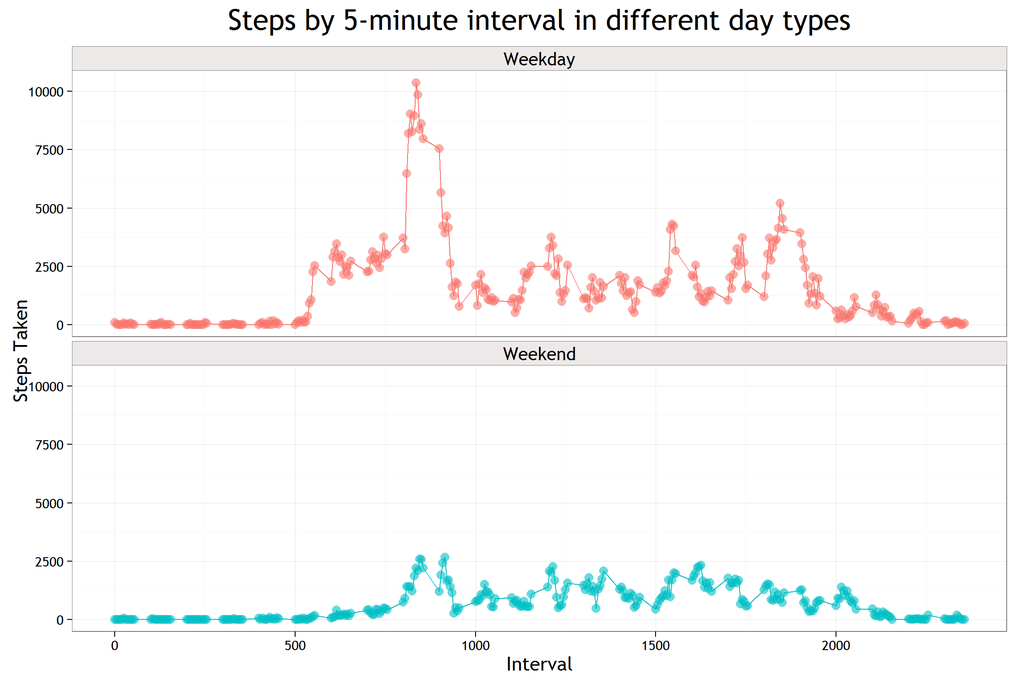

```r
##      Prepares the ggplot object with all the aestetics and features
gObj <- ggplot(ActivityByDayType, aes(Interval, AllSteps, font_family = "A"))
gObj <- gObj + theme_bw(base_family = "A", base_size = 14)
##      Adding panels by DayType in 2 rows
gObj <- gObj + facet_wrap(~ DayType, ncol = 1, nrow = 2)
gObj <- gObj + geom_point(aes(color = DayType),size = 3.5, alpha = .6)
gObj <- gObj + geom_line(aes(color = DayType))
##      Setting the annotations
gObj <- gObj + xlab("Interval")
gObj <- gObj + ylab("Steps Taken")
gObj <- gObj + ggtitle("Steps by 5-minute interval in different day types")
gObj <- gObj + theme(axis.title = element_text(family = "A", size = 16)
                , title = element_text(family = "A", size = 20)
                , plot.title = element_text(vjust = 2)
                , strip.text.x = element_text(size = 15)
                , strip.background = element_rect(fill = "snow2")
                , legend.position = "none"
                , legend.position = "none"
)
print(gObj)
```

*This is an* **extra chart** *just to compare both sets of data in one plot*

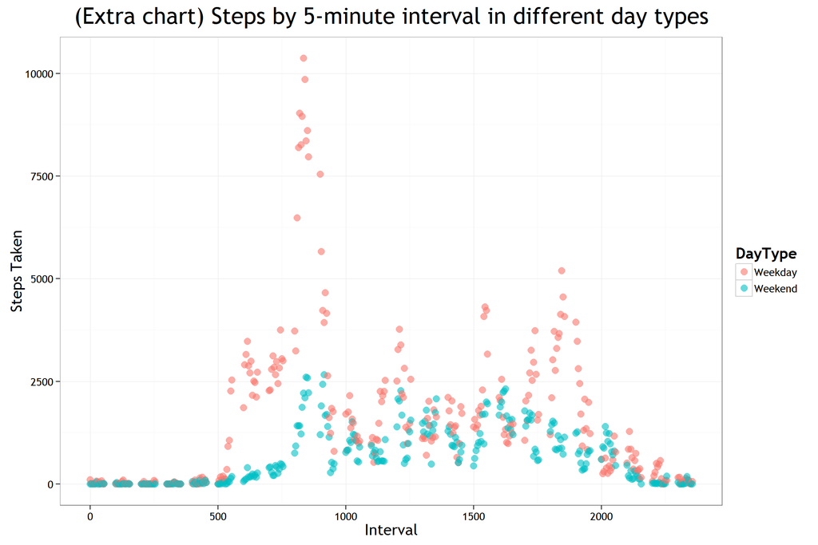

```r
gObj <- ggplot(ActivityByDayType, aes(Interval, AllSteps, font_family = "A"))
gObj <- gObj + theme_bw(base_family = "A", base_size = 14)
##      Adding panels by DayType in 2 rows
gObj <- gObj + geom_point(aes(color = DayType),size = 3.5, alpha = .6)
##      Setting the annotations
gObj <- gObj + xlab("Interval")
gObj <- gObj + ylab("Steps Taken")
gObj <- gObj + ggtitle("(Extra chart) Steps by 5-minute interval in different day types")
gObj <- gObj + theme(axis.title = element_text(family = "A", size = 16)
                , title = element_text(family = "A", size = 20)
                , plot.title = element_text(vjust = 2))
print(gObj)
```